# linear_models

Brian Seko

2023-08-17

The seoul_bike_sharing_converted_normalized.csv will be our main dataset which has following variables:

The response variable:

RENTED BIKE COUNT- Count of bikes rented at each hour Weather predictor variables:

TEMPERATURE - Temperature in Celsius HUMIDITY - Unit is % WIND_SPEED - Unit is m/s VISIBILITY - Multiplied by 10m DEW_POINT_TEMPERATURE - The temperature to which the air would have to cool down in order to reach saturation, unit is Celsius SOLAR_RADIATION - MJ/m2 RAINFALL - mm SNOWFALL - cm Date/time predictor variables:

DATE - Year-month-day HOUR- Hour of he day FUNCTIONAL DAY - NoFunc(Non Functional Hours), Fun(Functional hours) HOLIDAY - Holiday/No holiday SEASONS - Winter, Spring, Summer, Autumn

Let’s read the dataset as a dataframe first:

```r
# Dataset URL
dataset_url <- "https://cf-courses-data.s3.us.cloud-object-storage.appdomain.cloud/IBMDeveloperSkillsNetwork-RP0321EN-SkillsNetwork/labs/datasets/seoul_bike_sharing_converted_normalized.csv"
bike_sharing_df <- read_csv(dataset_url)
spec(bike_sharing_df)
```

We won’t be using the DATE column, because ‘as is’, it basically acts like an data entry index. (However, given more time, we could use the DATE colum to create a ‘day of week’ or ‘isWeekend’ column, which we might expect has an affect on preferred bike rental times.) We also do not need the FUNCTIONAL DAY column because it only has one distinct value remaining (YES) after missing value processing.

```r
bike_sharing_df <- bike_sharing_df %>%
                   select(-DATE, -FUNCTIONING_DAY)
```

TASK: Split training and testing data First, we need to split the full dataset into training and testing datasets.

The training dataset will be used for fitting regression models, and the testing dataset will be used to evaluate the trained models.

TODO: Use the initial_split(), training(), and testing() functions to generate a training dataset consisting of 75% of the original dataset, and a testing dataset using the remaining 25%.

```r
data_split <- initial_split(bike_sharing_df, prop = 0.75)

train_data <- training(data_split)
test_data <- testing(data_split)
```

TASK: Build a linear regression model using weather variables only As you could imagine, weather conditions may affect people’s bike renting decisions. For example, on a cold and rainy day, you may choose alternate transportation such as a bus or taxi. While on a nice sunny day, you may want to rent a bike for a short-distance travel.

Thus, can we predict a city’s bike-sharing demand based on its local weather information? Let’s try to build a regression model to do that.

TODO: Build a linear regression model called lm_model_weather using the following variables:

TEMPERATURE - Temperature in Celsius HUMIDITY - Unit is % WIND_SPEED - Unit is m/s VISIBILITY - Multiplied by 10m DEW_POINT_TEMPERATURE - The temperature to which the air would have to cool down in order to reach saturation, unit is Celsius SOLAR_RADIATION - MJ/m2 RAINFALL - mm SNOWFALL - cm Define a linear regression model specification.

Fit a model with the response variable RENTED_BIKE_COUNT and predictor variables TEMPERATURE + HUMIDITY + WIND_SPEED + VISIBILITY + DEW_POINT_TEMPERATURE + SOLAR_RADIATION + RAINFALL + SNOWFALL

```r
lm_model_weather_spec <- linear_reg() %>%
  set_engine("lm") %>%
  set_mode("regression")

weather_recipe <- recipe(RENTED_BIKE_COUNT ~ TEMPERATURE + HUMIDITY + WIND_SPEED + VISIBILITY + DEW_POINT_TEMPERATURE + SOLAR_RADIATION + RAINFALL + SNOWFALL, data = train_data)

lm_model_weather <- workflow() %>%
  add_model(lm_model_weather_spec) %>%
  add_recipe(weather_recipe)

lm_model_weather <- fit(lm_model_weather, data = train_data)

coefficients <- lm_model_weather$fit$fit$fit$coefficients
coefficients_df <- as.data.frame(t(coefficients), row.names = "Coefficients")

kable(coefficients_df, caption = "Summary of Weather Model")
```

Summary of Weather Model

|  | (Intercept) | TEMPERATURE | HUMIDITY | WIND_SPEED | VISIBILITY | DEW_POINT_TEMPERATURE | SOLAR_RADIATION | RAINFALL | SNOWFALL |
| --- | --- | --- | --- | --- | --- | --- | --- | --- | --- |
| Coefficients | 244.1314 | 1855.835 | -1141.02 | 370.6362 | 5.743741 | 237.9386 | -382.5953 | -2060.744 | 357.9096 |

Coefficients:

In this complex tapestry of weather factors, bike rentals ebb and flow like the changing seasons. The story of bike rentals is one of adaptation, where the demand for bikes is a dance with nature, intertwined with the elements of weather. It paints a picture of a city in motion, a city that responds and changes, embracing the sun’s warmth and retreating from the rain, all on two wheels.

Overall, the weather plays a complex role in bike rental demand, with clear and warm weather generally promoting rentals, and extreme conditions like * heavy rain acting as a deterrent. The insights can guide marketing and operational strategies, such as offering promotions on sunny days or providing additional services during rain.

#### ASK: Build a linear regression model using all variables

In addition to weather, there could be other factors that may affect bike rental demand, such as the time of a day or if today is a holiday or not.

Next, let’s build a linear regression model using all variables (weather + date/time) in this task.

TODO: Build a linear regression model called lm_model_all using all variables RENTED_BIKE_COUNT ~ . Print the fit summary for lm_model_all.

```r
lm_model_all_spec <- linear_reg() %>%
  set_engine("lm") %>%
  set_mode("regression")

lm_model_all <- workflow() %>%
  add_model(lm_model_all_spec) %>%
  add_formula(RENTED_BIKE_COUNT ~ .)

lm_model_all <- fit(lm_model_all, data = train_data)

# Print the summary of the lm object
summary(lm_model_all$fit$fit$fit)
```

```
##
## Call:
## stats::lm(formula = ..y ~ ., data = data)
##
## Residuals:
##      Min       1Q   Median       3Q      Max
## -1314.75  -216.10   -11.36   199.81  1806.10
##
## Coefficients: (3 not defined because of singularities)
##                        Estimate Std. Error t value Pr(>|t|)
## (Intercept)             313.602     52.067   6.023 1.81e-09 ***
## TEMPERATURE             407.706    213.318   1.911 0.056016 .
## HUMIDITY              -1077.949    102.198 -10.548  < 2e-16 ***
## WIND_SPEED              -14.178     39.540  -0.359 0.719938
## VISIBILITY                5.329     20.038   0.266 0.790304
## DEW_POINT_TEMPERATURE   991.854    223.806   4.432 9.51e-06 ***
## SOLAR_RADIATION         292.640     40.681   7.194 7.04e-13 ***
## RAINFALL              -2360.997    163.695 -14.423  < 2e-16 ***
## SNOWFALL                293.170     94.512   3.102 0.001931 **
## `\\`0\\``               -35.420     33.936  -1.044 0.296647
## `\\`1\\``              -131.588     33.897  -3.882 0.000105 ***
## `\\`10\\``             -243.471     33.365  -7.297 3.30e-13 ***
## `\\`11\\``             -247.639     33.839  -7.318 2.83e-13 ***
## `\\`12\\``             -214.263     34.358  -6.236 4.78e-10 ***
## `\\`13\\``             -210.662     34.546  -6.098 1.14e-09 ***
## `\\`14\\``             -205.869     34.690  -5.934 3.10e-09 ***
## `\\`15\\``             -105.783     34.256  -3.088 0.002024 **
## `\\`16\\``               16.756     33.739   0.497 0.619477
## `\\`17\\``              300.114     33.951   8.840  < 2e-16 ***
## `\\`18\\``              727.404     34.410  21.139  < 2e-16 ***
## `\\`19\\``              478.064     34.173  13.990  < 2e-16 ***
## `\\`2\\``              -248.975     33.703  -7.387 1.69e-13 ***
## `\\`20\\``              410.421     34.557  11.877  < 2e-16 ***
## `\\`21\\``              418.973     34.626  12.100  < 2e-16 ***
## `\\`22\\``              315.018     34.136   9.228  < 2e-16 ***
## `\\`23\\``               69.966     33.991   2.058 0.039593 *
## `\\`3\\``              -352.339     33.778 -10.431  < 2e-16 ***
## `\\`4\\``              -392.816     33.412 -11.757  < 2e-16 ***
## `\\`5\\``              -377.870     33.849 -11.163  < 2e-16 ***
## `\\`6\\``              -218.486     33.988  -6.428 1.38e-10 ***
## `\\`7\\``               104.009     33.571   3.098 0.001956 **
## `\\`8\\``               486.696     33.398  14.573  < 2e-16 ***
## `\\`9\\``                    NA         NA      NA       NA
## AUTUMN                  375.271     19.957  18.804  < 2e-16 ***
## SPRING                  204.426     19.147  10.677  < 2e-16 ***
## SUMMER                  210.269     28.850   7.288 3.52e-13 ***
## WINTER                       NA         NA      NA       NA
## HOLIDAY                -116.619     22.319  -5.225 1.80e-07 ***
## NO_HOLIDAY                   NA         NA      NA       NA
## ---
## Signif. codes:  0 '***' 0.001 '**' 0.01 '*' 0.05 '.' 0.1 ' ' 1
##
## Residual standard error: 373 on 6312 degrees of freedom
## Multiple R-squared:  0.6617, Adjusted R-squared:  0.6598
## F-statistic: 352.8 on 35 and 6312 DF,  p-value: < 2.2e-16
```

1. **Call**: Shows the function and parameters used to build the model.
2. **Residuals**: Residuals are the differences between the observed and predicted values. You can see the minimum, 1st quartile, median, 3rd quartile, and maximum residual values.
3. **Coefficients**: This is where the magic happens. Here’s what each column means:
   - **Estimate**: The estimated effect of each predictor on the target variable.
   - **Std. Error**: Standard error of the estimate; smaller values indicate more reliable estimates.
   - **t value**: The t-statistic, used to test the null hypothesis that the coefficient is zero.
   - **Pr(>|t|)**: The p-value; small values (typically less than 0.05) suggest that the coefficient is significantly different from zero.
   - **Signif. codes**: Asterisks denote significance levels. Three asterisks (e.g. `***`) indicate a highly significant coefficient.
4. **Singularities**: Some coefficients are not defined due to singularities. This means that there are linear dependencies among the predictors. For example, having “WINTER” and “NO_HOLIDAY” as undefined could be due to perfect collinearity with other season and holiday-related variables.
5. **Residual standard error**: Gives an idea of the spread of residuals around the fitted line. Lower values are usually better.
6. **Multiple R-squared**: Represents the proportion of variance in the dependent variable explained by the model. Higher values are generally better, indicating a better fit.
7. **Adjusted R-squared**: Similar to R-squared but adjusted for the number of predictors in the model. It’s a more balanced measure of goodness-of-fit, especially when dealing with a large number of predictors.
8. **F-statistic**: A test statistic for the overall significance of the model. A significant p-value here (< 2.2e-16) indicates that at least one of the predictors is related to the response variable.

ASK: Model evaluation and identification of important variables Now that you have built two regression models, lm_model_weather and lm_model_all, with different predictor variables, you need to compare their performance to see which one is better.

In this project, you will be asked to use very important metrics that are often used in Statistics to determine the performance of a model:

R^2 / R-squared Root Mean Squared Error (RMSE) R-squared

R squared, also known as the coefficient of determination, is a measure to indicate how close the data is to the fitted regression line. The value of R-squared is the percentage of variation of the response variable (y) that is explained by a linear model.

Root Mean Squared Error (RMSE) 𝑅𝑀𝑆𝐸=𝑀𝑆𝐸⎯⎯⎯⎯⎯⎯⎯⎯⎯⎯√

As you know, the Mean Squared Error measures the average of the squares of errors, where ‘error’ is the difference between the actual value ( 𝑦 ) and the estimated value ( ŷ ). Another metric that is related to MSE is Root Mean Squared Error (RMSE) and is simply the square root of MSE.

We first need to test the lm_model_weather and lm_model_all models against the test dataset test_data, and generate RENTED_BIKE_COUNT prediction results.

TODO: Make predictions on the testing dataset using both lm_model_weather and lm_model_all models

```r
predictions_weather <- predict(lm_model_weather, new_data = test_data %>% select(-RENTED_BIKE_COUNT))
predictions_all <- predict(lm_model_all, new_data = test_data %>% select(-RENTED_BIKE_COUNT))
rmse_weather <- rmse(test_data$RENTED_BIKE_COUNT, pull(predictions_weather))
rmse_all <- rmse(test_data$RENTED_BIKE_COUNT, pull(predictions_all))

print(paste("RMSE for lm_model_weather:", rmse_weather))
```

```
## [1] "RMSE for lm_model_weather: 495.275753078121"
```

```r
print(paste("RMSE for lm_model_all:", rmse_all))
```

```
## [1] "RMSE for lm_model_all: 379.170695703583"
```

Since lm_model_all has many predictor variables, let’s check which predictor variables have larger coefficients. Variables with larger coefficients in the model means they attribute more in the prediction of RENTED_BIKE_COUNT. In addition, since all predictor variables are normalized to the same scale, 0 to 1, we thus can compare their coefficients directly.

You could try building another regression model using the non-normalized seoul_bike_sharing_converted.csv dataset, and you would find that the coefficients are much different.

First let’s print all coefficients:

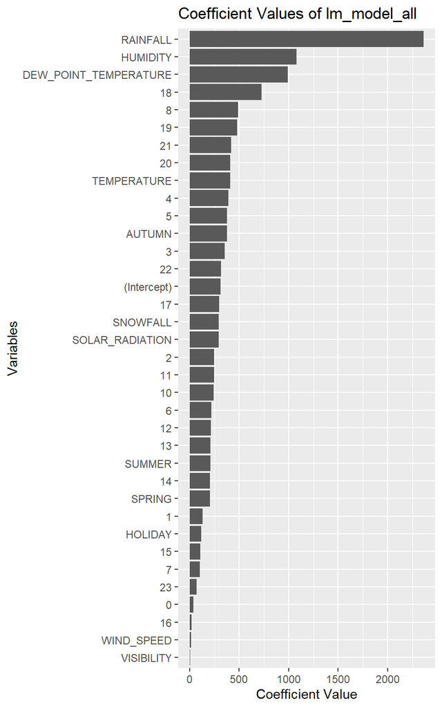

```r
# Extracting coefficients and creating a dataframe
coeffs <- lm_model_all$fit$fit$fit$coefficients
coeffs_df <- as.data.frame(abs(coeffs))
coeffs_df$names <- rownames(coeffs_df)
colnames(coeffs_df)[1] <- "coeffs" # Renaming the coefficient column

# Sorting the coefficients in descending order
coeffs_df <- coeffs_df[order(-coeffs_df$coeffs),]

coeffs_df$names <- gsub("`", "", coeffs_df$names)
coeffs_df$names <- gsub("\\\\", "", coeffs_df$names)

# Plotting the coefficients using ggplot2
ggplot(coeffs_df %>% filter(!is.na(coeffs)), aes(x = reorder(names, coeffs), y = coeffs)) +
  geom_bar(stat = "identity") +
  coord_flip() +
  xlab("Variables") +
  ylab("Coefficient Value") +
  ggtitle("Coefficient Values of lm_model_all")
```

The factors “rainfall,” “humidity,” and “dew point temperature” appearing as the most important predictors in the regression model for bike rentals can be summarized for their significance as follows:

Rainfall:

Direct Impact on Comfort: Rain can directly affect the comfort level of riding a bike. Wet conditions make roads slippery and increase the risk of accidents. Perceived Inconvenience: People may perceive riding a bike in the rain as inconvenient or uncomfortable, especially without proper gear. Alternative Transportation: During rainy weather, potential bikers might opt for public transportation or private vehicles to stay dry. Humidity:

Physical Discomfort: High humidity can make physical exertion feel more strenuous, leading to discomfort during biking. Impact on Health: Extremely high or low humidity might have health implications for some individuals, making them less likely to engage in physical activities like biking. Seasonal Patterns: Humidity might also correlate with certain seasons, where people’s biking behavior might change due to weather patterns and associated activities. Dew Point Temperature:

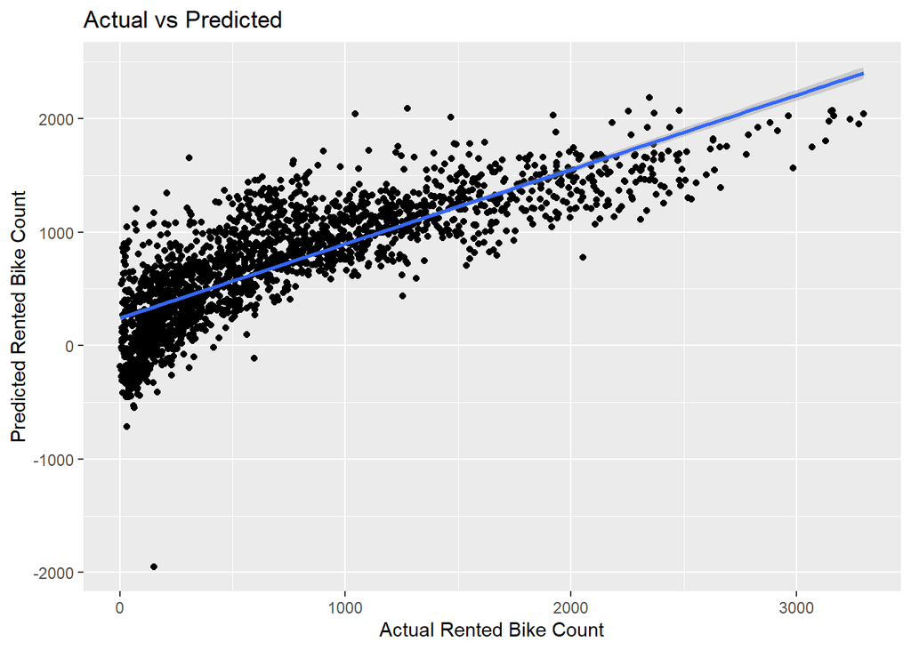

```r
comparison_data <- data.frame(Predictions = pull(predictions_all), Actual = test_data$RENTED_BIKE_COUNT)

ggplot(comparison_data, aes(x = Actual, y = Predictions)) +
  geom_point() +                   # Scatter plot of actual vs predictions
  geom_smooth(method = 'lm') +     # Linear regression line
  ggtitle("Actual vs Predicted") +
  xlab("Actual Rented Bike Count") +
  ylab("Predicted Rented Bike Count")
```

This will create a scatter plot showing the relationship between the actual and predicted values. Points closer to the diagonal line indicate predictions that are closer to the actual values, while points further from the line indicate larger errors.

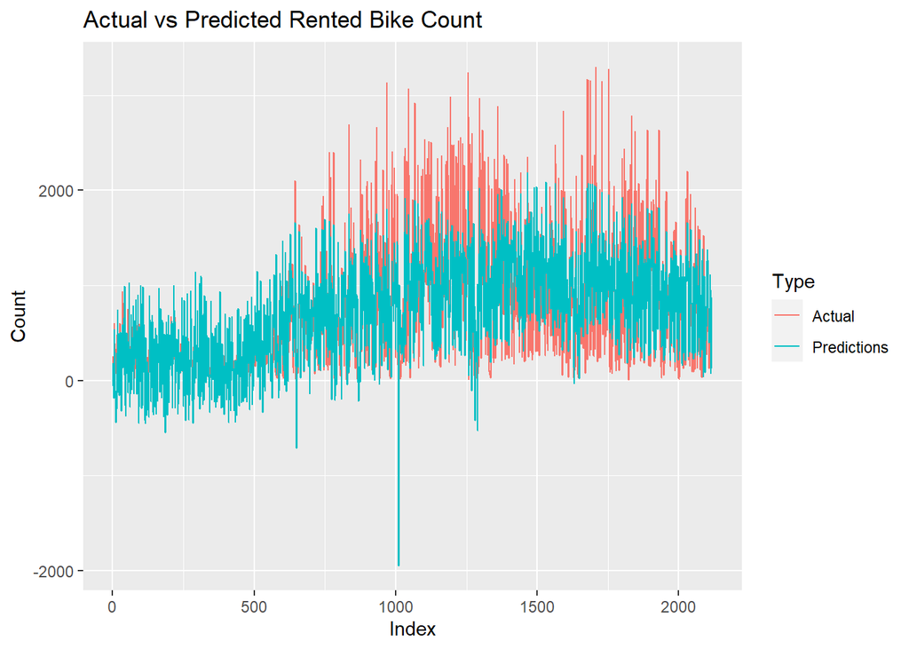

```r
comparison_data$Index <- 1:nrow(comparison_data)

comparison_data_long <- comparison_data %>%
  pivot_longer(cols = c("Actual", "Predictions"), names_to = "Type", values_to = "Count")

ggplot(comparison_data_long, aes(x = Index, y = Count, color = Type)) +
  geom_line() +
  ggtitle("Actual vs Predicted Rented Bike Count") +
  xlab("Index") +
  ylab("Count")
```